# Computer Assignment #5 Phase #1

#### Effect of using different activation functions

First we test a model that has Leaky ReLU as activation function of its hidden layers. Leaky ReLU is defined as below:

$$LeakyReLU(x) = \begin{cases} x & \text{if } x \geq 0 \\ ax & \text{if } x < 0 \\ \end{cases}$$

which $a$ is a small constant.(for example 0.01)

```
Test results:
 F1:0.33, Precision:0.75, Recall:0.50 Accuracy:0.4927
Train results:
 F1:0.33, Precision:0.75, Recall:0.50 Accuracy:0.501825
```

```
Test results:
 F1:0.33, Precision:0.75, Recall:0.50 Accuracy:0.4927
Train results:
 F1:0.33, Precision:0.75, Recall:0.50 Accuracy:0.501825
```

```
Test results:
 F1:0.43, Precision:0.75, Recall:0.55 Accuracy:0.5415
Train results:
 F1:0.43, Precision:0.75, Recall:0.55 Accuracy:0.54975
```

```
Test results:
 F1:0.79, Precision:0.83, Recall:0.80 Accuracy:0.7957
Train results:
 F1:0.80, Precision:0.83, Recall:0.80 Accuracy:0.799725
```

```
Test results:
 F1:0.87, Precision:0.87, Recall:0.87 Accuracy:0.8698
Train results:
 F1:0.88, Precision:0.88, Recall:0.88 Accuracy:0.878225
```

```
Test results:
 F1:0.86, Precision:0.87, Recall:0.86 Accuracy:0.8623
Train results:
 F1:0.87, Precision:0.88, Recall:0.87 Accuracy:0.87325
```

```
Test results:
 F1:0.83, Precision:0.86, Recall:0.84 Accuracy:0.835
Train results:
 F1:0.85, Precision:0.88, Recall:0.85 Accuracy:0.85265
```

```
Test results:
 F1:0.88, Precision:0.88, Recall:0.88 Accuracy:0.8831
Train results:
 F1:0.90, Precision:0.90, Recall:0.90 Accuracy:0.904425
```

```
Test results:
 F1:0.88, Precision:0.88, Recall:0.88 Accuracy:0.8783
Train results:
 F1:0.91, Precision:0.91, Recall:0.91 Accuracy:0.906025
```

```
Test results:
 F1:0.88, Precision:0.88, Recall:0.88 Accuracy:0.881
Train results:
 F1:0.91, Precision:0.91, Recall:0.91 Accuracy:0.90595
```

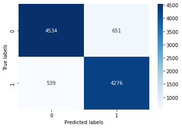

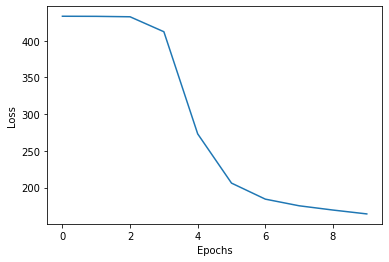

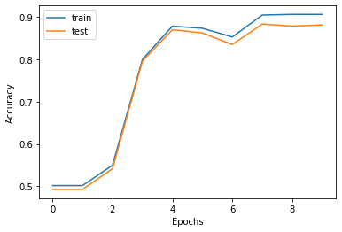

```python
NEURONS = 64
train_loader, test_loader = generate_data_loader()
model = create_model([
    MyLinear_mod(3000,NEURONS),
    nn.LeakyReLU(),
    MyLinear_mod(NEURONS, NEURONS),
    nn.LeakyReLU(),
    MyLinear_mod(NEURONS, NEURONS),
    nn.LeakyReLU(),
    MyLinear_mod(NEURONS, 1),
    nn.Sigmoid()
])

train_leaky, test_leaky, losses_leaky = train_model(model, train_loader, test_loader, learning_rate=0.1)
```

*What's the advantage of using Leaky ReLU instead of ReLU?*

Leaky ReLU is sometimes considered better than traditional ReLU because it can address the "dying ReLU" problem, which can occur when the gradient of the ReLU function becomes zero for negative inputs. This can cause neurons to stop learning during the training process and become unresponsive to any further updates.

```
Test results:
 F1:0.45, Precision:0.75, Recall:0.56 Accuracy:0.5537
Train results:
 F1:0.47, Precision:0.75, Recall:0.56 Accuracy:0.5659
```

```
Test results:
 F1:0.79, Precision:0.82, Recall:0.80 Accuracy:0.7935
Train results:
 F1:0.79, Precision:0.82, Recall:0.79 Accuracy:0.795275
```

```
Test results:
 F1:0.53, Precision:0.77, Recall:0.60 Accuracy:0.6057
Train results:
 F1:0.53, Precision:0.77, Recall:0.60 Accuracy:0.60325
```

```
Test results:
 F1:0.87, Precision:0.88, Recall:0.87 Accuracy:0.8738
Train results:
 F1:0.89, Precision:0.89, Recall:0.89 Accuracy:0.889225
```

```
Test results:
 F1:0.88, Precision:0.88, Recall:0.88 Accuracy:0.8782
Train results:
 F1:0.90, Precision:0.90, Recall:0.90 Accuracy:0.896525
```

```
Test results:
 F1:0.88, Precision:0.88, Recall:0.88 Accuracy:0.8806
Train results:
 F1:0.90, Precision:0.90, Recall:0.90 Accuracy:0.904125
```

```
Test results:
 F1:0.88, Precision:0.88, Recall:0.88 Accuracy:0.8779
Train results:
 F1:0.90, Precision:0.90, Recall:0.90 Accuracy:0.900525
```

```
Test results:
 F1:0.88, Precision:0.88, Recall:0.88 Accuracy:0.8823
Train results:
 F1:0.91, Precision:0.91, Recall:0.91 Accuracy:0.9054
```

```
Test results:
 F1:0.85, Precision:0.87, Recall:0.85 Accuracy:0.8519
Train results:
 F1:0.87, Precision:0.89, Recall:0.88 Accuracy:0.875375
```

```
Test results:
 F1:0.88, Precision:0.88, Recall:0.88 Accuracy:0.8759
Train results:
 F1:0.91, Precision:0.91, Recall:0.91 Accuracy:0.906925
```

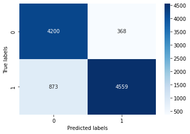

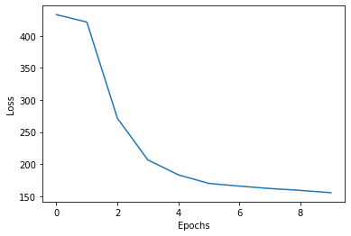

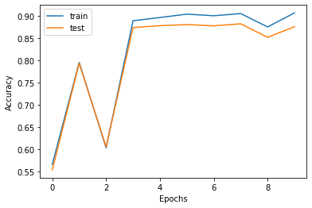

```python
NEURONS = 64
train_loader, test_loader = generate_data_loader()
model = create_model([
    MyLinear_mod(3000,NEURONS),
    nn.Tanh(),
    MyLinear_mod(NEURONS, NEURONS),
    nn.Tanh(),
    MyLinear_mod(NEURONS, NEURONS),
    nn.Tanh(),
    MyLinear_mod(NEURONS, 1),
    nn.Sigmoid()
])

train_leaky, test_leaky, losses_leaky = train_model(model, train_loader, test_loader, learning_rate=0.1)
```

```
Test results:
 F1:0.33, Precision:0.75, Recall:0.50 Accuracy:0.4927
Train results:
 F1:0.33, Precision:0.75, Recall:0.50 Accuracy:0.501825
```

```
Test results:
 F1:0.33, Precision:0.75, Recall:0.50 Accuracy:0.4927
Train results:
 F1:0.33, Precision:0.75, Recall:0.50 Accuracy:0.501825
```

```
Test results:
 F1:0.33, Precision:0.75, Recall:0.50 Accuracy:0.4927
Train results:
 F1:0.33, Precision:0.75, Recall:0.50 Accuracy:0.501825
```

```
Test results:
 F1:0.33, Precision:0.75, Recall:0.50 Accuracy:0.4927
Train results:
 F1:0.33, Precision:0.75, Recall:0.50 Accuracy:0.501825
```

```
Test results:
 F1:0.33, Precision:0.75, Recall:0.50 Accuracy:0.4927
Train results:
 F1:0.33, Precision:0.75, Recall:0.50 Accuracy:0.501825
```

```
Test results:
 F1:0.33, Precision:0.75, Recall:0.50 Accuracy:0.4927
Train results:
 F1:0.33, Precision:0.75, Recall:0.50 Accuracy:0.501825
```

```
Test results:
 F1:0.34, Precision:0.75, Recall:0.50 Accuracy:0.5073
Train results:
 F1:0.33, Precision:0.75, Recall:0.50 Accuracy:0.498175
```

```
Test results:
 F1:0.33, Precision:0.75, Recall:0.50 Accuracy:0.4927
Train results:
 F1:0.33, Precision:0.75, Recall:0.50 Accuracy:0.501825
```

```
Test results:
 F1:0.33, Precision:0.75, Recall:0.50 Accuracy:0.4927
Train results:
 F1:0.33, Precision:0.75, Recall:0.50 Accuracy:0.501825
```

```
Test results:
 F1:0.34, Precision:0.75, Recall:0.50 Accuracy:0.5073
Train results:
 F1:0.33, Precision:0.75, Recall:0.50 Accuracy:0.498175
```

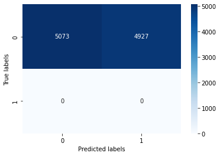

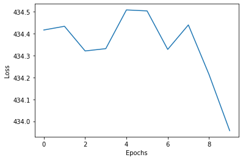

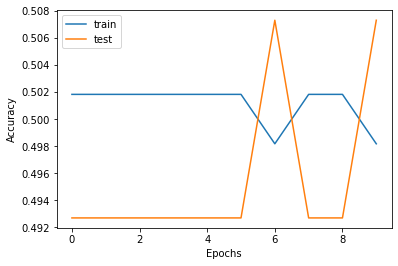

```python
NEURONS = 64
train_loader, test_loader = generate_data_loader()
model = create_model([
    MyLinear_mod(3000,NEURONS),
    nn.Sigmoid(),
    MyLinear_mod(NEURONS, NEURONS),
    nn.Sigmoid(),
    MyLinear_mod(NEURONS, NEURONS),
    nn.Sigmoid(),
    MyLinear_mod(NEURONS, 1),
    nn.Sigmoid()
])

train_leaky, test_leaky, losses_leaky = train_model(model, train_loader, test_loader, learning_rate=0.1)
```

*Why using Sigmoid or Tanh for hidden layers is a bad choice?*

Sigmoid and tanh activation functions have a limited output range, which can cause the gradients to become very small when the input is far from the origin. This can result in the gradients "vanishing" or becoming too small to be useful during backpropagation, especially in deep neural networks with many layers. As a result, the model may take a long time to converge, or may not converge at all.

Although, in our case, using Tanh for hidden layers wasn't bad and worked well.

#### Effect of batch size

```
Test results:
 F1:0.79, Precision:0.83, Recall:0.80 Accuracy:0.7978
Train results:
 F1:0.80, Precision:0.83, Recall:0.81 Accuracy:0.804925
```

```
Test results:
 F1:0.86, Precision:0.87, Recall:0.86 Accuracy:0.8575
Train results:
 F1:0.87, Precision:0.89, Recall:0.87 Accuracy:0.875275
```

```
Test results:
 F1:0.87, Precision:0.88, Recall:0.88 Accuracy:0.8749
Train results:
 F1:0.90, Precision:0.90, Recall:0.90 Accuracy:0.901825
```

```
Test results:
 F1:0.88, Precision:0.88, Recall:0.88 Accuracy:0.8811
Train results:
 F1:0.91, Precision:0.91, Recall:0.91 Accuracy:0.907875
```

```
Test results:
 F1:0.87, Precision:0.88, Recall:0.87 Accuracy:0.8727
Train results:
 F1:0.90, Precision:0.91, Recall:0.90 Accuracy:0.903675
```

```
Test results:
 F1:0.87, Precision:0.88, Recall:0.87 Accuracy:0.8741
Train results:
 F1:0.90, Precision:0.91, Recall:0.90 Accuracy:0.902325
```

```
Test results:
 F1:0.87, Precision:0.88, Recall:0.87 Accuracy:0.8723
Train results:
 F1:0.90, Precision:0.91, Recall:0.90 Accuracy:0.904125
```

```
Test results:
 F1:0.88, Precision:0.88, Recall:0.88 Accuracy:0.8775
Train results:
 F1:0.91, Precision:0.91, Recall:0.91 Accuracy:0.91105
```

```
Test results:
 F1:0.85, Precision:0.87, Recall:0.85 Accuracy:0.8489
Train results:
 F1:0.87, Precision:0.89, Recall:0.88 Accuracy:0.875975
```

```
Test results:
 F1:0.88, Precision:0.88, Recall:0.88 Accuracy:0.8788
Train results:
 F1:0.92, Precision:0.92, Recall:0.92 Accuracy:0.91545
```

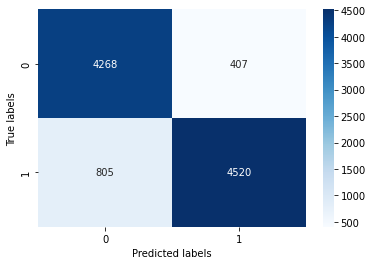

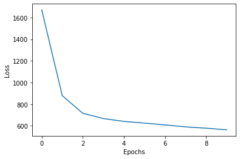

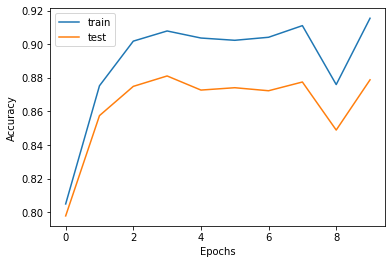

```python
NEURONS = 64
train_loader, test_loader = generate_data_loader(batch_size=16)
model = create_model([
    MyLinear_mod(3000,NEURONS),
    MyReLU_mod(),
    MyLinear_mod(NEURONS, NEURONS),
    MyReLU_mod(),
    MyLinear_mod(NEURONS, NEURONS),
    MyReLU_mod(),
    MyLinear_mod(NEURONS, 1),
    nn.Sigmoid()
])

train_losses, test_accuracys, train_accuacys = train_model(model, train_loader, test_loader)
```

```
Test results:
 F1:0.33, Precision:0.75, Recall:0.50 Accuracy:0.4927
Train results:
 F1:0.33, Precision:0.75, Recall:0.50 Accuracy:0.501825
```

```
Test results:
 F1:0.33, Precision:0.75, Recall:0.50 Accuracy:0.4927
Train results:
 F1:0.33, Precision:0.75, Recall:0.50 Accuracy:0.501825
```

```
Test results:
 F1:0.34, Precision:0.75, Recall:0.50 Accuracy:0.5073
Train results:
 F1:0.33, Precision:0.75, Recall:0.50 Accuracy:0.498175
```

```
Test results:
 F1:0.33, Precision:0.75, Recall:0.50 Accuracy:0.4927
Train results:
 F1:0.33, Precision:0.75, Recall:0.50 Accuracy:0.501825
```

```
Test results:
 F1:0.33, Precision:0.75, Recall:0.50 Accuracy:0.4927
Train results:
 F1:0.33, Precision:0.75, Recall:0.50 Accuracy:0.501825
```

```
Test results:
 F1:0.34, Precision:0.75, Recall:0.50 Accuracy:0.5073
Train results:
 F1:0.33, Precision:0.75, Recall:0.50 Accuracy:0.498175
```

```
Test results:
 F1:0.34, Precision:0.75, Recall:0.50 Accuracy:0.5073
Train results:
 F1:0.33, Precision:0.75, Recall:0.50 Accuracy:0.498175
```

```
Test results:
 F1:0.33, Precision:0.75, Recall:0.50 Accuracy:0.4927
Train results:
 F1:0.33, Precision:0.75, Recall:0.50 Accuracy:0.50195
```

```
Test results:
 F1:0.33, Precision:0.75, Recall:0.50 Accuracy:0.4927
Train results:
 F1:0.33, Precision:0.75, Recall:0.50 Accuracy:0.5019
```

```
Test results:
 F1:0.33, Precision:0.75, Recall:0.50 Accuracy:0.4927
Train results:
 F1:0.33, Precision:0.75, Recall:0.50 Accuracy:0.501825
```

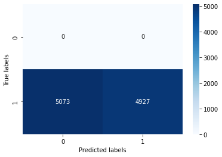

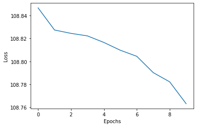

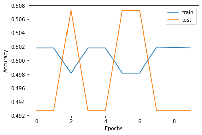

```python
NEURONS = 64
train_loader, test_loader = generate_data_loader(batch_size=256)
model = create_model([
    MyLinear_mod(3000,NEURONS),
    MyReLU_mod(),
    MyLinear_mod(NEURONS, NEURONS),
    MyReLU_mod(),
    MyLinear_mod(NEURONS, NEURONS),
    MyReLU_mod(),
    MyLinear_mod(NEURONS, 1),
    nn.Sigmoid()
])

train_losses, test_accuracys, train_accuacys = train_model(model, train_loader, test_loader)
```

*Why do we use batch in training and what are the advantages and disadvantages of small or big batch size?*

This is done for memory and computational efficiency, as well as improved generalization. By training on smaller batches, we can reduce the memory requirements and computational cost of training, and help the model to generalize better to new data.

High batch size:

- Training on a large number of samples before making updates to the weights can lead to faster convergence during the training process.
- However, a high batch size can also lead to overfitting, where the model becomes too specialized to the training data and performs poorly on new, unseen data.
- Additionally, a high batch size can require a large amount of memory, which can limit the size of the model that can be trained.

Low batch size:

- Updating the weights more frequently can help to avoid overfitting and lead to better generalization performance.
- However, a low batch size can also lead to slower convergence during the training process, as the gradient estimates become less accurate with a smaller batch size.
- So a low batch size can increase the noise and variability in the gradient estimates, which can make the training process more unstable.